# Exploring Corruption Policies outcomes worlwide

By: **StudentA**, **StudentB** and **StudentC**

Our group is interested in corruption. This is how corruption is behaving worldwide:

```r
dataLink="https://github.com/EvansDataScience/basicFinal_VISUAL/raw/master/dataProject.csv"
df=read.csv(dataLink,stringsAsFactors = FALSE)
```

These are the contents:

```r
str(df)
```

```
## 'data.frame':    153 obs. of  6 variables:
##  $ iso       : chr  "ALB" "DZA" "AGO" "ARG" ...
##  $ country   : chr  "Albania" "Algeria" "Angola" "Argentina" ...
##  $ corruption: int  39 34 18 36 33 79 75 30 43 26 ...
##  $ economy   : num  7.54 4.84 5.4 4.88 7.6 7.99 7.66 6.38 7.38 6.32 ...
##  $ press     : num  60 48.2 50 64.8 61.1 ...
##  $ Continent : chr  "Europe" "Africa" "Africa" "S_America" ...
```

## Univariate plots:

```r
summary(df$corruption)
```

```
##    Min. 1st Qu.  Median    Mean 3rd Qu.    Max.
##   13.00   30.00   38.00   44.16   57.00   90.00
```

The variable corruption measures how well countrues are facing it. Then, 75% of the countries achieve at most a score of 57. No country achieves a score greater than 90.

You can see the distribution here:

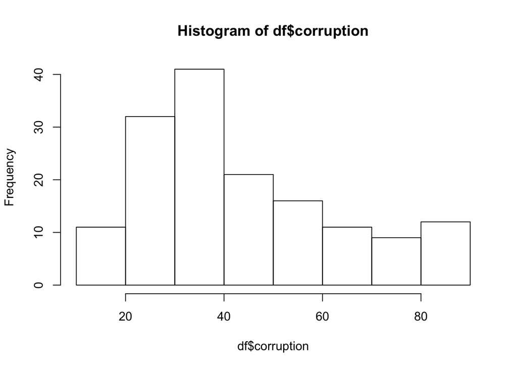

```r
hist(df$corruption)
```

That plot does not allow to find if we have outliers, for that we need a boxplot:

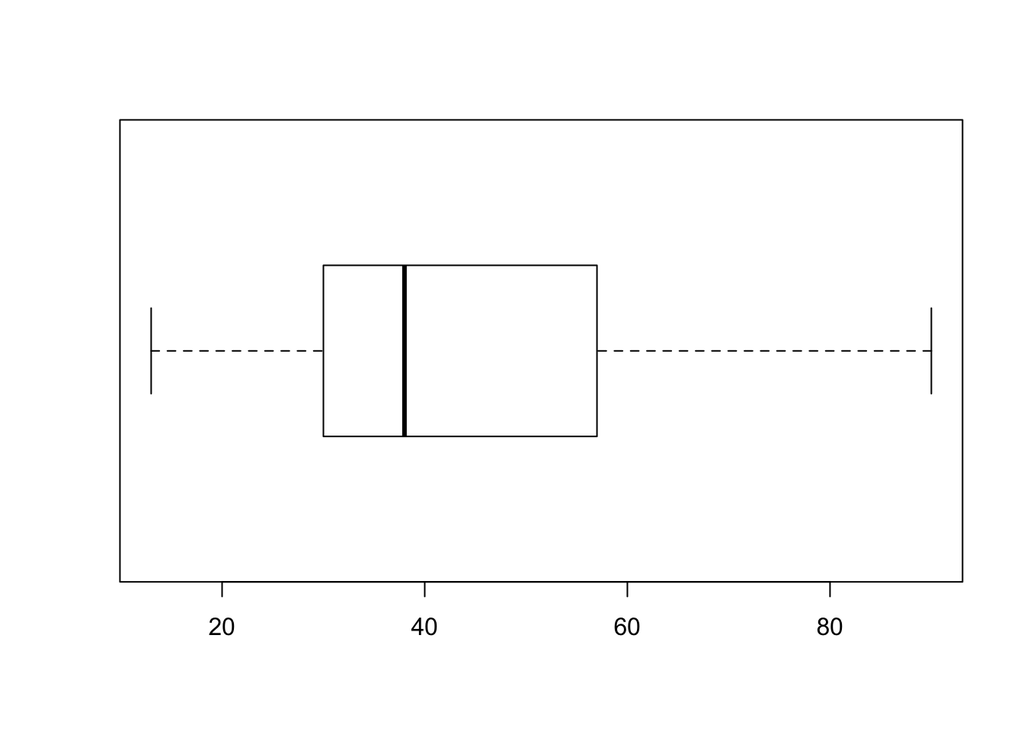

```r
boxplot(df$corruption,horizontal = TRUE)
```

## Bivariate plots:

Let me see the median of corruption by continent:

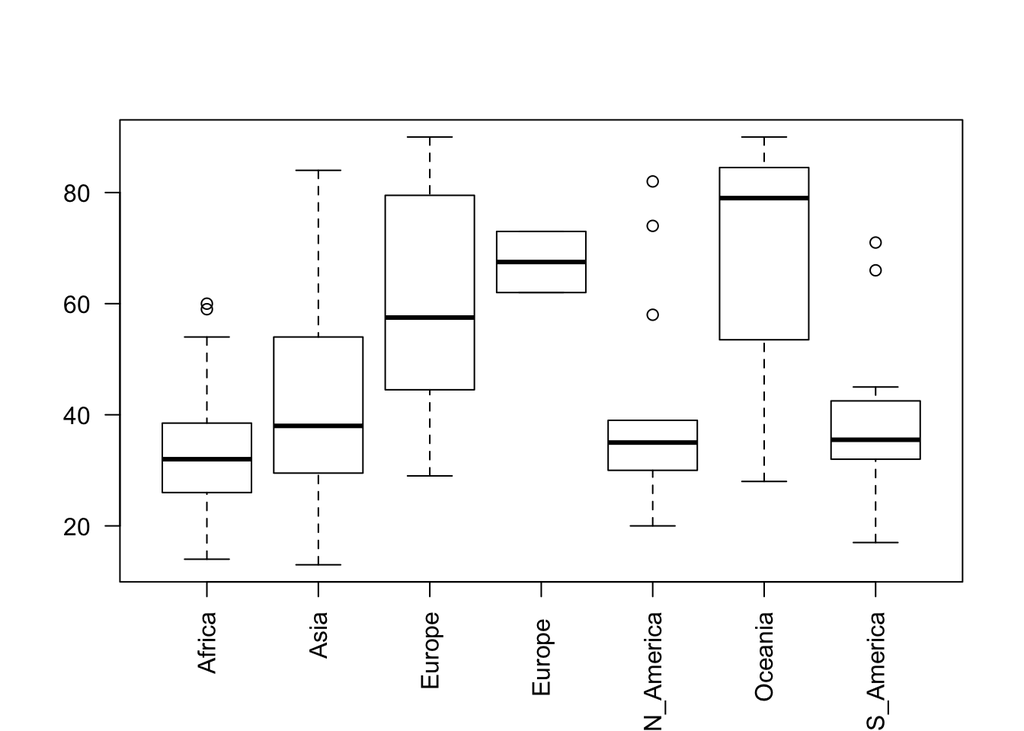

```r
boxplot(df$corruption~df$Continent,horizontal = FALSE,las=2)
```

The total did not detect outliers, but the bivariate exploration did. Let’s see if those median values are statistically different:

```r
# non parametric
kruskal.test(corruption~factor(Continent), data = df)
```

[output not shown]

We should wonder what variables could explain this variability worldwide.

Let me see how each of the proposed predictors relates to our dependent variable:

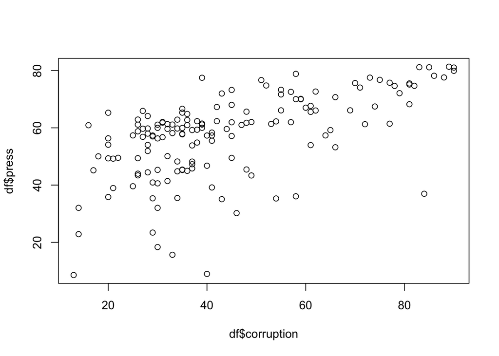

```r
plot(df$corruption,df$press)
```

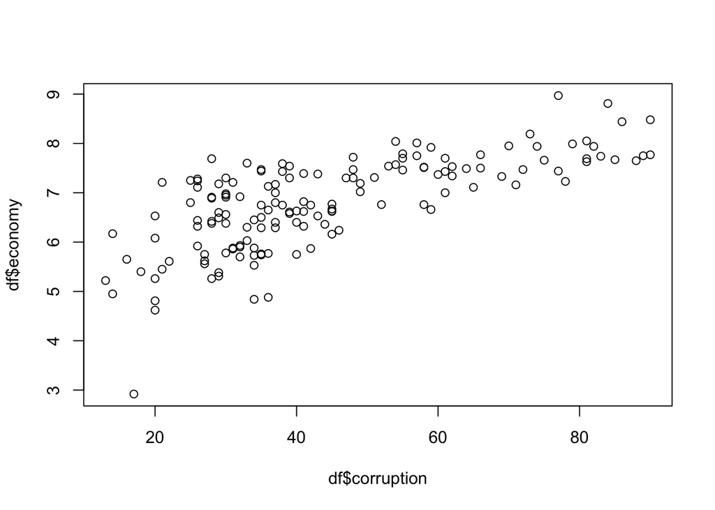

```r
plot(df$corruption,df$economy)
```

## Multivariate plots:

We know that the predictors have a fairly linear relationship with the dependent variable, then we can test our hypothesis by seeing the effect of each controlling by the other:

```r
test=lm(as.numeric(corruption)~press+economy,data=df)
```

The result is shown here:

```r
summary(test)
```

```
##
## Call:
## lm(formula = as.numeric(corruption) ~ press + economy, data = df)
##
## Residuals:
##      Min       1Q   Median       3Q      Max
## -25.6113  -7.2466  -0.3429   8.1577  25.2325
##
## Coefficients:
##              Estimate Std. Error t value Pr(>|t|)
## (Intercept) -61.88179    7.37537  -8.390 3.32e-14 ***
## press         0.45142    0.07453   6.057 1.07e-08 ***
## economy      11.79973    1.17397  10.051  < 2e-16 ***
## ---
## Signif. codes:  0 '***' 0.001 '**' 0.01 '*' 0.05 '.' 0.1 ' ' 1
##
## Residual standard error: 12.22 on 150 degrees of freedom
## Multiple R-squared:  0.6035, Adjusted R-squared:  0.5982
## F-statistic: 114.2 on 2 and 150 DF,  p-value: < 2.2e-16
```

A helpful plot will help us show the effect of those predictors on corruption.

```r
library(dotwhisker)
library(broom)
library(dplyr)
```

There is some preprocessing needed to use ggplot.

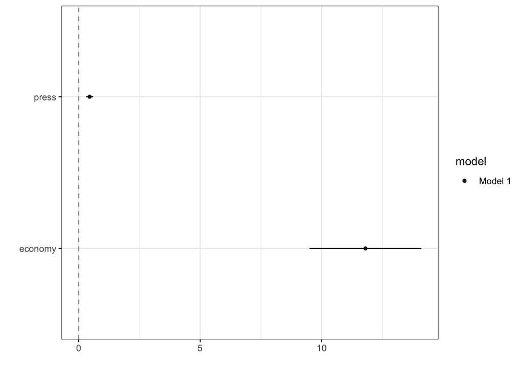

```r
model1_t = tidy(test) %>%
    mutate(model = "Model 1")

dwplot(model1_t) +
    geom_vline(xintercept = 0,
               colour = "grey60",
               linetype = 2) +
    scale_colour_grey(start = .1, end = .7) +theme_bw()
```

```r
library(cluster)
set.seed(123)

# computing clusters
result <- kmeans(df[,c(3:5)],
                 centers = 5)

df$cluster=as.factor(result$cluster)
```

Let’s see the median of each cluster:

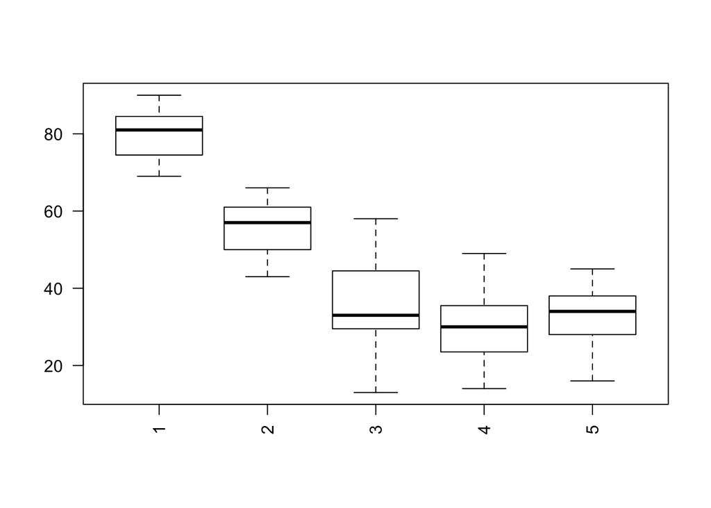

```r
boxplot(df$corruption~df$cluster,horizontal = FALSE,las=2)
```

We should recode the las two clusters:

```r
library(car)
df$cluster<-car::recode(df$cluster,"4=5;5=4")
```

And see how the world looks like.

Let me show you the map:

```r
library(rgdal)
```

```r
folder='world_map'
file='world_map.shp'
mapFile=file.path(folder,file)

#original map
mapWorld = rgdal::readOGR(mapFile,stringsAsFactors=F)
```

The *mapWorld* file has the following columns:

```r
names(mapWorld)
```

```
##  [1] "FIPS"      "ISO2"      "ISO3"      "UN"        "NAME"
##  [6] "AREA"      "POP2005"   "REGION"    "SUBREGION" "LON"
## [11] "LAT"
```

Then, we can merge that file with our current data frame:

```r
# NEW map
mapWorldAll=merge(mapWorld, #map first
                   df,
                   by.x='ISO3', # common column
                   by.y='iso', # common column
                   all.x=F) # reduced map.
```

Now paint the world:

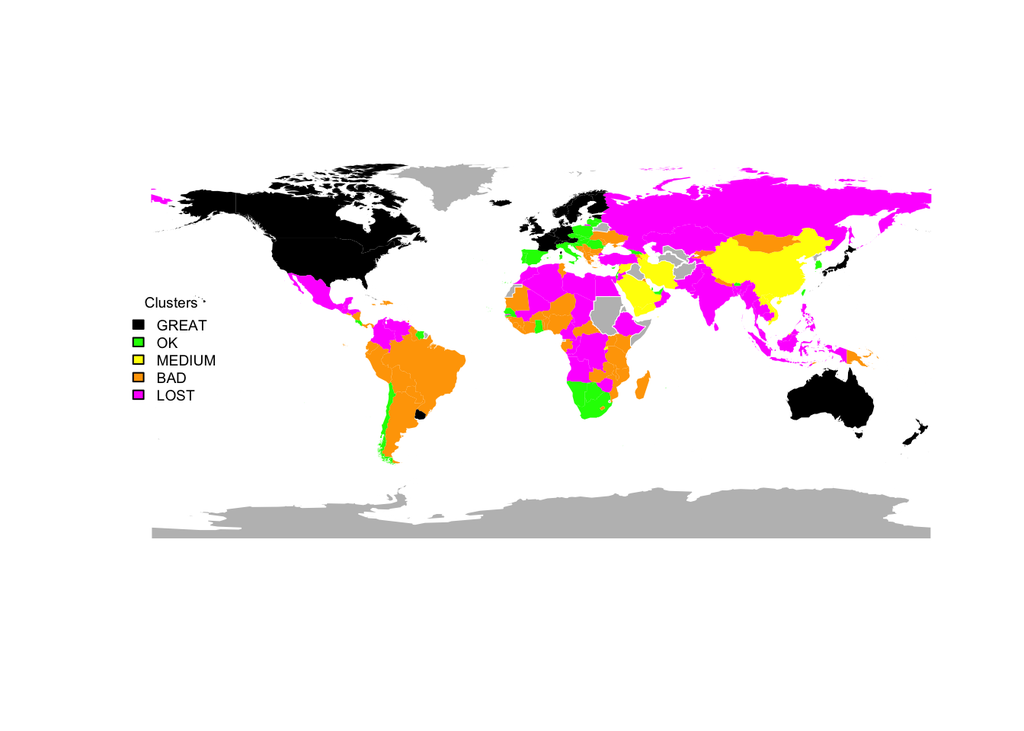

```r
# what:
varToPlot=mapWorldAll$cluster

#which colors: (order of clusters)

palette = c('black','green','yellow','orange','magenta')

# plotting:

## base layer (original map)
plot(mapWorld,col='grey',border=0)

## top layer
plot(mapWorldAll, col = palette[varToPlot],border=F,add=T)


legend('left', legend = c("GREAT",'OK',"MEDIUM","BAD","LOST"),
       fill = palette,
       cex = 0.6,
       bty = "n",
       title="Clusters")
```

[GO BACK TO REPO](https://github.com/EvansDataScience/basicFinal_VISUAL)